# A/B testing, Bayes style

## But why?

So that you understand your test results correctly, including the uncertainty in them, without the p-value hassle.

### Also:

Gentle introduction to Bayesian methods.

### After this

You understand the results of Bayesin analysis, and are familiar with terms such as *posterior*, *prior*, and *statistical model*.

## Our case

Reaktor website has a one-click purchase of a fixed-price-scope schedule-team agile software project, or whatever. There are *two variants of the button*.

Which is better? How much?

**What do we measure**?

Visits on the page and button clicks.

**What do we want to know**?

The probablity that the visitor clicks on the button to buy

= click rate

## Collected data

Simulated data for a day, average 2000 visit on the page

20% of visitors see option **B**

```
 day variant visits clicks click.rate
   1       A   1188     59 0.04966330
   1       B    322     24 0.07453416
```

## Bayesian result

Posterior probability distribution of click rates

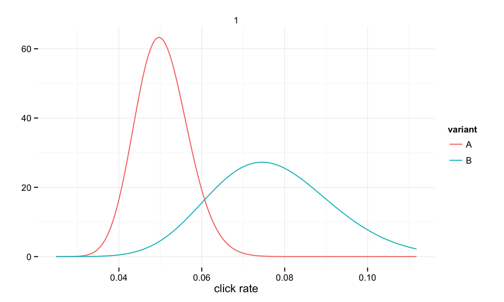

## Problems with the usual way

Check classical results here: http://abtestguide.com/calc/

I get:

- Average conversion rate (*ok, I get this*)
- P-value (*probablity of obtaining the data when null hypothesis is true … WTF*)
- Z-score (*no idea what this is*)
- Confidence intervals (*I've been told that nobody understands*)

Loads of other numbers I don't understand

## What's behind Bayesian result

Assumption: visitor on page has probablity **P<sub>A</sub>** of clicking the button when shown variant **A** and **P<sub>B</sub>** when shown **B**. Visits are independent of each other

- For those interested, this is called binomial model

Before collecting any data I have an opinnion what the click rate is. Here the opinnion was: I know nothing, all values (between 0 and 1) **P<sub>A</sub>** and **P<sub>B</sub>** are equally good.

- The opinnion *must* be included in the analysis, even when it is "I don't know"
- This is called the *prior*

## What do the results mean

Exactly what you think they do (maybe).

The meaning of the of click rate distribution is exactly the same thing as when you say that your *estimate* of the rain probability for tomorrow is between 20% and 30%.

## The cycle

State your knowledge about the click rates. Can be "*I know nothing*". This is your *prior* distribution.

Define your model how data is generated in your process (Visitors have a probability **P** to click the button).  
Ask your local Scientology dealer for help

Collect data

Do Bayesian analysis (or ask someone to do it for you), it is the method of updating the knowledge with the collected data

You get *posterior* distribution, the knowledge we have about the click rates *given that we have the observed data*.

## Fun facts

Prior and posterior distributions mean the same thing: it is the mathematical representation of our knowledge including the uncertainty in it (narrow or wide distribution).

In the next experiment (or next day of same experiment) we can, and should use the previous posterior as our prior

Posterior (or prior) contain all the information we have and everything can be calculated from it. Like "How much **A** is better than **B**?", "How certain we are that **A** is really better than **B**" etc.

## From clicks to posterior

```
 day variant visits clicks click.rate
   1       A   1555     78 0.05016077
   1       B    336     24 0.07142857
   2       A    984     53 0.05386179
   2       B    330     27 0.08181818
   3       A   1303     58 0.04451266
   3       B    325     26 0.08000000
   4       A   1619     97 0.05991353
   4       B    233     23 0.09871245
   5       A   1392     70 0.05028736
   5       B    224     25 0.11160714
   6       A   1752     73 0.04166667
   6       B    292     14 0.04794521
```

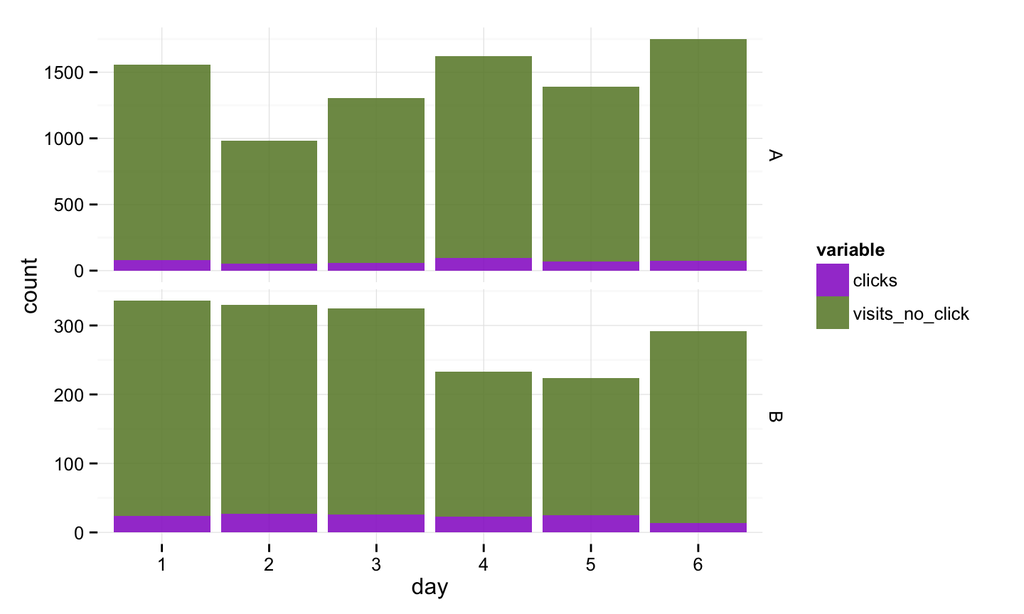

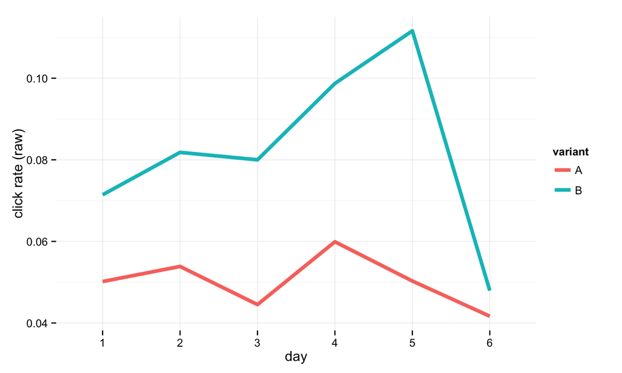

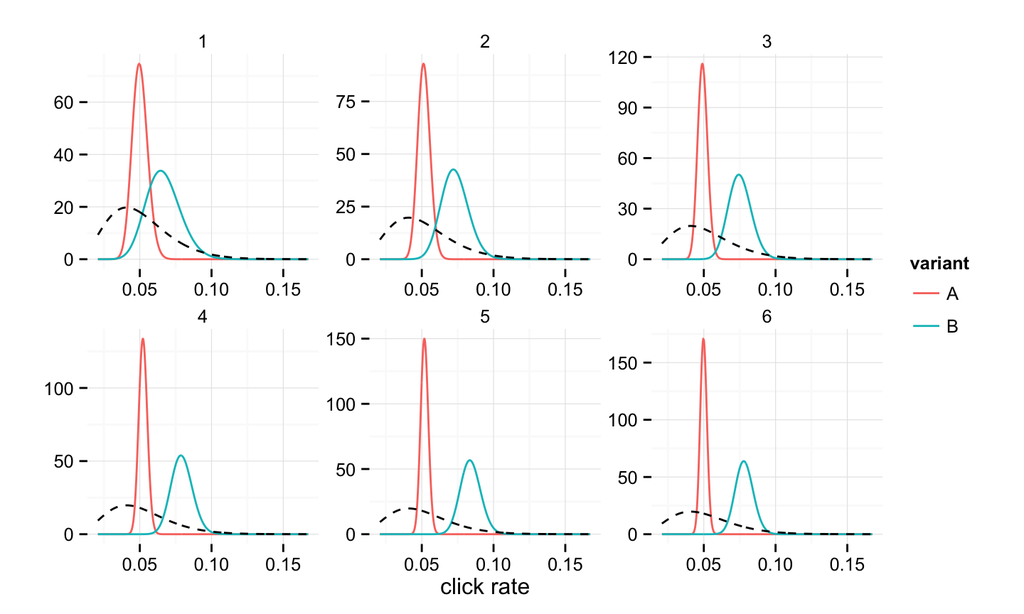